# Preparing ddRAD loci for subsequent analyses

J. Ignacio Lucas Lledó

2025-03-16

## Extraction of consensus FASTA from ddRAD loci

According to the analysis in `2023-05-17b`, I choose `ipyrad`’s output corresponding to a clustering threshold of 0.95. I first generate FASTA files for every locus, with different alleles of the same individual as different sequences. That is, I will start by distributing allelic sequences found in `../2023-05-17b/crepi95_outfiles/crepi95.alleles` in locus-specific FASTA files.

```bash
ALLELES=../2023-05-17b/crepi95_outfiles/crepi95.alleles
if [ ! -e summary_alleles.txt ]; then
   echo -e "Locus\tLength\tNumSeqs\tNumVar\tNumInfor" > summary_alleles.txt
   if [ ! -d alleles ]; then mkdir alleles; fi
   gawk '(/^[^\/]/){
      SEQ[$1] = $2
      N++
      LEN = length($2)
   }(/^\//){
      split($0, A, /\|/)
      N1 = gsub(/*/, "*", A[1])
      N2 = gsub(/-/, "-", A[1])
      FASTAOUT = sprintf("alleles/loc%07i.fa", A[2])
      for (s in SEQ) print ">" s "\n" SEQ[s] >FASTAOUT
      print sprintf("loc%07i.fa", A[2]) "\t" LEN "\t" N "\t" N1 + N2 + 0 "\t" N1 >>"summary_alleles.txt"
      delete SEQ
      N = 0
   }' $ALLELES
fi
```

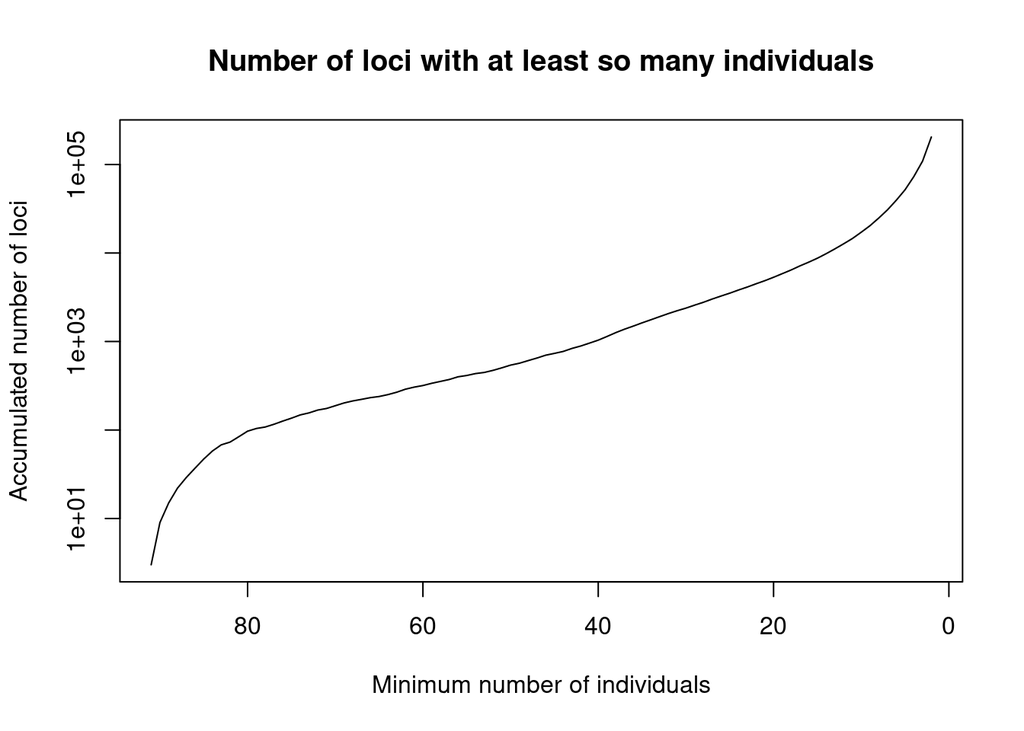

```r
suppressMessages(library(kableExtra))
Alleles <- read.table('summary_alleles.txt', header = TRUE)
NumInd <- as.data.frame(table(Alleles$NumSeqs / 2), stringsAsFactors = FALSE)
names(NumInd) <- c('NumInd', 'NumLoci')
NumInd$NumInd <- as.integer(NumInd$NumInd)
NumInd <- NumInd[order(NumInd$NumInd, decreasing = TRUE),]
NumInd$CumSum <- cumsum(NumInd$NumLoci)
plot(NumInd$NumInd, NumInd$CumSum,
     xlim = c(max(NumInd$NumInd), min(NumInd$NumInd)), type = 'l', log = 'y',
     xlab = 'Minimum number of individuals',
     ylab = 'Accumulated number of loci',
     main = 'Number of loci with at least so many individuals')
```

```r
kable(NumInd, row.names = FALSE,
      col.names = c('Number of individuals', 'Number of loci', 'Cumulative Sum')) %>% kable_styling(full_width = FALSE)
```

| Number of individuals | Number of loci | Cumulative Sum |
| --- | --- | --- |
| 91 | 3 | 3 |
| 90 | 6 | 9 |
| 89 | 6 | 15 |
| 88 | 7 | 22 |
| 87 | 7 | 29 |
| 86 | 8 | 37 |
| 85 | 10 | 47 |
| 84 | 11 | 58 |
| 83 | 10 | 68 |
| 82 | 5 | 73 |
| 81 | 11 | 84 |
| 80 | 13 | 97 |
| 79 | 7 | 104 |
| 78 | 4 | 108 |
| 77 | 8 | 116 |
| 76 | 10 | 126 |
| 75 | 10 | 136 |
| 74 | 12 | 148 |
| 73 | 8 | 156 |
| 72 | 12 | 168 |
| 71 | 7 | 175 |
| 70 | 13 | 188 |
| 69 | 14 | 202 |
| 68 | 11 | 213 |
| 67 | 9 | 222 |
| 66 | 10 | 232 |
| 65 | 7 | 239 |
| 64 | 12 | 251 |
| 63 | 16 | 267 |
| 62 | 22 | 289 |

[output cut: 60 more lines]

I use the `cons` program from EMBOSS to get the consensus sequence from every locus.

```bash
if [ ! -e consensus.fa ]; then
   if [ ! -d tmp ]; then mkdir tmp; fi
   for l in $(ls -1 alleles); do
      NAME=$(basename -s .fa $l)
      cons -sequence alleles/$l -outseq tmp/$l -name $NAME 2> /dev/null
      cat tmp/$l >> consensus.fa
   done
   #rm -r tmp
fi
```

The file `consensus.fa` contains all loci, irrespective of how few samples have been sequenced there. It can be used as a reference to map original reads in FASTQ files, in order to generate the BAM files corresponding to these loci. Mapping failures would reduce the coverage, with respect to what is observed in the `alleles` folder. But in general I would expect the mapping to generate similar alignments, with the advantage of sequence quality information, from which to estimate genotype likelihoods.

## What’s next

In order to use the alignments for an extended Bayesian skyline plot, I need to be able to assign population labels to individuals. One option is to stick to the lake. But we know there is some more structure. If I want to determine the structure of genetic variation before assuming populations, I need a decent common matrix of genotypes.

One good reason not to have a complete matrix of genotypes is that many reads were wasted in `ipyrad` due to low-coverage. We had set the `mindepth_majrule` to 4, which excludes from the analysis any sample-specific cluster with less than 4 reads. This makes sense for the purpose of knowing genotypes, but it’s a waste of information in the context of genotype likelihoods.

One possibility is to run `ipyrad` again with `mindepth_majrule` set to 1. But we would lose the base-quality information with which genotype likelihoods can be estimated, and we would miss a lot of heterozygous genotypes. It may be worth trying, for the methods to be more consistent. But it would be as having in every locus a mixture of haploid and diploid individuals, without knowing which homozygotes are the haploid ones.

The strategy of re-mapping the raw reads to all cluster consensus seems more promissing. That way, we would get BAM files, suitable to work with ANGSD.